# GCCR Factor Influence

Aliaksandr Panko

August 20, 2019

# GCCR - Global Compact Compliance Rules.

GCCR is the set of rules. Companies that fulfill these rules are considered as “good”

The analysis includes 5 universes:

- Equity USA (MSCI index).
- Equity Europe (MSCI index).
- Equity Emerging markets (MSCI index).
- Bonds (manually splitted into Junk Bonds and Investment Grade Bonds. The universe is represented by the bank of america merrill corporate index for the U.S. and Europe).

The MSCI Indices are designed to measure the performance of the large- and mid-cap segments of a market.

As of December 2018:

- For the USA market it covered more than 600 constituents and approximately 85% of the free float-adjusted market capitalization in the U.S.
- The MSCI Europe Index included 15 developed markets having more than 400 constituents and covered approximately 85% of the free float-adjusted market capitalization across the European developed market equity universe.
- The MSCI Emerging Markets Index included securities in 26 Emerging Markets having more than 1100 constituents and covered approximately 85% of the free float-adjusted market capitalization in each country.

# Data Features

- Sustainability filter is actually not only GCCR and is updated monthly.
- The filter was filled backward from Feb. 2016 (first time).
- There were unexpected jumps in August-September 2018. This looked like some data features/issues.
- We updated data container, now it is backward filled from 2018.
- Still there are data inconsistency in containers (the universes are not the same any more). Corrected manually.
- There are 2 sources of unreliable solition caused by backward filling.
- Data Issue 1: the scores are not changing significantly. Since we backward filled GCCR data with recent “scores” we ignore the fact that they could improve during last 10 years.
- Data Issue 2: the look-ahead (survivorship) bias. GCCR filter has 3 values: 1,0,NA for every date. Values 1 and 0 are set to index constituents and NAs are set elsewhere. Applying GCCR (that was backward filled) and investing only in 1-s 10 years ago gives you the companies that survived in the index until 2018, additionally ignoring some other companies that could also have 1-s that time but just did not survive until 2018.

# USA: Number of Companies in the Universe

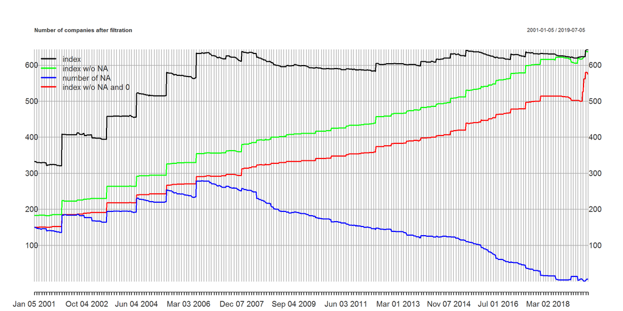

# USA: Number of Companies in the Universe. Summary

- “index” is MSCI. As expected, the value is around 600.
- We can see a pattern in NA: the number of NA gradually decreases. This is expected, since caused by construction of SustFilter, which was backward-filled. NA value in SustFilter is assigned to a company that did not survive till 2018 (date of backward-filling). Obviously, the number of companies that did not survive till 2018 in, say, 2006 is much greater than this number in 2017.
- “index w/o NA” is MSCI universe without companies, which have NA in SustFilter container. Obviously, in the end we have the same value as index (by construction of SustFilter). Looking at the difference between black and green lines we can see how many companies are not survived until 2018. We can notice that in 2006 we ignore around 50% of companies, in 2010 around 30% and from 2015 less than 10%.
- The difference between red line and green line shows how many companies are excluded just because of SustFilter. It’s around 17%.
- Notice the jump in red line: the jump means that suddenly number of “good” companies increased by around 80 = 16% (huge!). This could have been explained by increase in “index”, but we do not see it. Also we do not see any drops in NA. However, this could be explained by switching to “rating +” SustFilter universe.
- Final hypothesis: initially we had SustFilter data for S&P500 (that explaines 17% hard filtering, when only 10% is supposed to be filtered), than in the beggining of 2019 we switched to “rating +” (more companies became available, so we have a jump). After that all the NAs were set to 0 (that explaines why we do not see a drop in NAs). Then we decided to backward fill the data from 2018 to have NAs (so we have correct NAs picture before 2018 and wrong after)